# Lab 8 - Summarizing Insights and Data Gaps

## Instructions and Overview

In this final lab, you will curate what you have discovered across previous labs - both summarizing insights and critiquing knowledge gaps. This text will be added to an “About” page on your data dashboard. You should write each section outlined below as if you were presenting this data to someone else. What should others know about the data? How best can you summarize the diverse issues running through the data? You likely have written much of this content in other labs. The objective of this lab is to selectively pull from what you’ve written in other labs, draw new connections across your analyses, and summarize key issues so that you can present your data publicly. However, be careul not to just copy and paste random snippets from other labs. Be sure that the text flows in a way that conveys something to a viewer.

## Getting Started

### Load the relevant libraries

```r
library(tidyverse)
library(lubridate)
library(shiny)
library(shinydashboard)
library(shinyWidgets)
```

### Import and clean example datasets

```r
hospitals <- read.csv("datasets/Hospitals.csv", stringsAsFactors = FALSE)

cases <- read.csv("https://raw.githubusercontent.com/CSSEGISandData/COVID-19/master/csse_covid_19_data/csse_covid_19_time_series/time_series_covid19_confirmed_global.csv", stringsAsFactors = FALSE)

#Do not worry about this line of code for now. Since the cases data gets appended every day with a new column representing that day's case counts, if we want the total cases per country, we need to add up all of the previous day's counts into a new column. The column below does this for us.
cases <-
  cases %>%
  mutate(Total.Cases =
           cases %>%
           select(starts_with("X")) %>%
           rowSums()
         ) %>%
  select(Province.State, Country.Region, Total.Cases)

hospitals$ZIP <- as.character(hospitals$ZIP)

hospitals$ZIP <- str_pad(hospitals$ZIP, 5, pad = "0")

is.na(hospitals) <- hospitals == "NOT AVAILABLE"
is.na(hospitals) <- hospitals == -999
is.na(cases) <- cases == ""

hospitals$SOURCEDATE <- ymd_hms(hospitals$SOURCEDATE)
hospitals$VAL_DATE <- ymd_hms(hospitals$VAL_DATE)
hospitals <- hospitals %>%
  mutate(SOURCEDATE_YEAR = year(SOURCEDATE))
```

### Import and clean your dataset.

```r
#Copy and paste relevant code from Lab 4 to import your data here.
ipps <- read.csv("https://data.cms.gov/api/views/tcsp-6e99/rows.csv?$limit=200000", stringsAsFactors = FALSE)

#Copy and paste relevant code from Lab 4 to clean your data here. This includes any row binding, character removals, converions in variable type, date formatting, or NA conversions.
str(ipps)
```

```
'data.frame':   196325 obs. of  12 variables:
 $ DRG.Definition                            : chr  "023 - CRANIOTOMY W MAJOR DEVICE IMPLANT OR ACUTE CNS PDX W MCC OR CHEMOTHE" "025 - CRANIOTOMY & ENDOVASCULAR INTRACRANIAL PROCEDURES W MCC" "027 - CRANIOTOMY & ENDOVASCULAR INTRACRANIAL PROCEDURES W/O CC/MCC" "037 - EXTRACRANIAL PROCEDURES W MCC" …
 $ Provider.Id                               : int  10001 10001 10001 10001 10001 10001 10001 10001 10001 10001 ...
 $ Provider.Name                             : chr  "SOUTHEAST ALABAMA MEDICAL CENTER" "SOUTHEAST ALABAMA MEDICAL CENTER" "SOUTHEAST ALABAMA MEDICAL CENTER" "SOUTHEAST ALABAMA MEDICAL CENTER" ...
 $ Provider.Street.Address                   : chr  "1108 ROSS CLARK CIRCLE" "1108 ROSS CLARK CIRCLE" "1108 ROSS CLARK CIRCLE" "1108 ROSS CLARK CIRCLE" ...
 $ Provider.City                             : chr  "DOTHAN" "DOTHAN" "DOTHAN" "DOTHAN" ...
 $ Provider.State                            : chr  "AL" "AL" "AL" "AL" ...
 $ Provider.Zip.Code                         : int  36301 36301 36301 36301 36301 36301 36301 36301 36301 36301 ...
 $ Hospital.Referral.Region..HRR..Description: chr  "AL - Dothan" "AL - Dothan" "AL - Dothan" "AL - Dothan" ...
 $ Total.Discharges                          : int  28 32 11 12 17 41 14 21 47 17 ...
 $ Average.Covered.Charges                   : num  117118 98358 69154 100427 58199 ...
 $ Average.Total.Payments                    : num  25824 20688 11811 19134 8519 ...
 $ Average.Medicare.Payments                 : num  24057 19791 8194 18154 6715 ...
```

## Summarize Data Source

Referring back to lab 3, in about 150 words, summarize your dataset and some of the things you learned about the historical and cultural context of your dataset. Note that this section can be almost word-for-word how you introduce your dataset in your final presentation (see criteria 4 in the final presentation assignment on Canvas). The only thing that may be different than in your final presentation is that you do not need to reference the data limitations *in this section*, as you will elaborate on them later in this assignment. This section should include all of the following:

1. What the data represents
2. Who produced it
3. Its observational unit
4. Some variables that describe that observational unit
5. A bit of its history/context from Lab 3

> Example: “The analysis presented in this dashboard is based on a dataset put out by the US EPA [<– who produced it] that documents the environmental compliance and enforcement history of every EPA-regulated facility in the US, including prisons [<– what it represents]. For every EPA-regulated facility in the US in a given year [<– observational unit], the dataset reports information such as the permits the facility has been awarded, enforcement actions taken against the facility, and penalties it has assessed [<– variables]. The EPA has been integrating this data from a number of different compliance databases for major federal regulations (such as the Clean Air Act and the Safe Drinking Water Act) for over ten years. Since states populate many of the databases on which ECHO relies, there are sometimes disparities in how data is reprsented from state to state as a result of different reporting procedures, data collection technologies, database infrastrucutres, local laws, and political incentives to report values accurately [<– history/context].”

```r
The data analysis within this dashboard is based on a dataset released by the Centers for Medicare and Medicaid Services (CMS) which records the inpatient discharges for Medicare fee-for-fee beneficiaries. The dataset is organized by hospital and Medicare Severity Diagnosis Related Group (MS-DRG) all in the fiscal year 2017. The dataset includes information on payment: total payment, Medicare payment, and hospital-specific charges. In addition to total discharges for each hospital-specific charge. The main source for the CMS data comes form the Medicare Provider Analysis Review (MEDPAR). Which contains information on all medicare beneficiaries using hospital services. This data has been annually produced since the fiscal year of 2011. However, only in 2014 were all MS-DRGs reported in the data. Prior years were only limited to the top 100 most prevalent discharges. Additionally, Maryland has had a Medicare Waiver since 2014 which permits Maryland hospitals to receive more federal government aid for its Medicare patients at a higher rate compared to other states but are capped at a global budget.
```

## Summarize Questions for Analysis

Referring back to labs 4-6, what were some of the questions you were posing as you approached your data exploration? What were you hoping to learn from your analysis that this particular dataset may have been able to help address? List at least three questions below, and indicate why you were asking each question. Make sure that the questions you list are relevant to this specific dataset.

```r
Which hospitals are receiving the most and least medicare payments?
This tells use which hospitals are most popular with medicare patients and have a big influence on the the data we see reported.
Which states in the U.S. have the widest distribution of diabetes cases with major complications?
Answer to this question tells us which states are treating medicare patients with diabetes combined with a major complication.
Which hospitals in the U.S. have the most total discharges?
Helps indicate which U.S. hospitals are treating the most medicare patients.
```

## Summarize Insights

In about 300 words, describe some conclusions that you were able to interpret *from your data analysis.* Each point you make in this section should do two things. First, you should reference specific empirical evidence that you were able to extrapolate from your data (through plots, charts, etc.), and second, you should *interpret* this evidence. This means that it is not enough to say that the average annual income in x community was $30000. What does that mean? Why should I, or anyone looking at your data, care about this value you calculated? If you were talking to someone that has the power to make decisions on your topic, what would you want that person to think after seeing your results? Note that you will reference quantitative insights when you show your empirical evidence, but you will reference issues beyond the data as you interpret the results. Some additional criteria for this section:

1. Be sure to contextualize your findings in the appropriate temporal and geographic context.
- Imprecise: “There are more general acute care hospitals than any other hospital.”
- Better: “Based on data aggregated from government sources by Oak Ridge National Laboratory since 2012, there are more general acute care hospitals in the United States than any other type of hospital. This data was last updated in 2018.”
2. Consider you sample.
- Imprecise: “There are 7146 open hospitals in the US according to data aggregated by the Oak Ridge National Laboratory.”
- Better: “There are 7146 open hospitals in the US according to data aggregated by the Oak Ridge National Laboratory. This does not include nursing homes or health centers.”
3. Make a clear distinction between what the data empirically shows you and how you interpret the results.
- Imprecise: “This data indicates that many hospitals do not have enough beds to take on new patients.”
- Better: “According to this data, the median number of beds at general acute hospitals in the US is 139. Comparing this to the case rates in the US since January, this suggests that many hospitals will not have enough beds available to take on the influx in patients if case rates continue to grow exponentially.”
4. Consider your data issues:
- Imprecise: “From January to present Covid-19 has spread most dramatically in the US.”
- Better: “From January to present Covid-19 confirmed cases has spread most dramatically in the US. However, with various regulatory, financial, social, and material barriers to testing potential cases, it is difficult to know the extent to which this data is representative of the actual spread of the virus.”

```r
There are 563 unique DRGs represented in the dataset built by CMS.  Each year CMS makes adjustments and may add new DRGs to the classification system. This reveals that the data is continuously being mutated. Additionally, through data analysis I uncovered  that the Florida Hospital had the most discharges on any U.S. hospital in 2017 with 32924 total discharges.  Showcasing how much this one medical center services the medicare community. Especially within its location in Orlando, Florida. This is important to notice because such a large institution will most likely be impacted heavily to any changes to medicare and medicaid coverage. It warrants further investigation on what the portion of the hospital’s yearly patients rely on Medicare. Secondly the New York-Presbyterian Hospital receives the highest amount of medicare payments within the United States at a total average of $10178377 dollars. This tells us that the hospital relies heavily on Medicare payments and services a large population. Finally, according to the dataset the cities of Boston, Springfield, and Worcester take in the most average total payments.
```

## Characterize Knowledge Gaps

Knowledge gaps refer to the things that we don’t know due to the fact that certain data was not collected, was not collected accurately, was not collected in a format or categorization structure that allowed us to attend to an issue, or was not documented. When presenting data, knowledge gaps are often just as important to document as insights as they communicate the limits of our analysis, and possibilities for either future research or improvements to the data. I list five different types of knowledge gaps below, and pose questions we might ask for each. You should respond to *three* of the questions below in about 50-100 words each in relation to your data.

### Inaccurate Data

Inaccurate data refers to data that is just incorrect. Typos and other data entry issues may constitute inaccurate data. For instance, sometimes addresses in a dataset may be misspelled, making it hard to geo-code those addresses. Or perhaps someone forgot to put a decimal point in a number increasing by the value by a power of 10. Inaccurate data can also refer to deliberate misreporting. Think about the firefighters that deliberately entered stopwatch data incorrectly as they were afraid of losing their jobs based on RAND’s data analysis in Joe Flood’s *The Fires*. Or consider countries and states that are deliberately under-reporting Covid-19 case counts so that they can justify opening businesses sooner.

In what ways might the data in your dataset be inaccurate? Describe in specific detail how these inaccuracies might affect your data analysis. Reference a specific analysis you’ve completed (either through transformation or plotting), and describe how this issue might impact how you interpret your data analysis.

```r
Data may be inaccurate in many cases mostly in DRG classification. It relies primarily on the physician to decide which DRG to classify the patient in and they are limited to unique categories that the CMS provides for that year. Considering that the DRG is the determining factor on the flat rate of pay the hospital receives. A physician may be motivated to classify a certain diagnosis with comorbidity or a major complication to gain more funding. Not to mention each hospital may have different procedures regarding when it’s necessary to add comorbidity or MCC to a patient’s diagnosis. Furthermore, it neglects to mention exactly what the cause of the major complication was. One example is my distribution box plots on diabetes with MCC. It has no representation on diabetes without complications and doesn’t tell us what the most common causes of complications could be.
```

### Incomplete Data

Incomplete data refers to data that does not cover the scope of an issue that we need to address. Sometimes this is because specific values in the dataset are missing (or appearing as NAs). For instance, in the hospitals dataset there are a number of hospitals in which no BEDS variable was recorded. Some of these hospitals are currently (or at the time of data collection) operating.

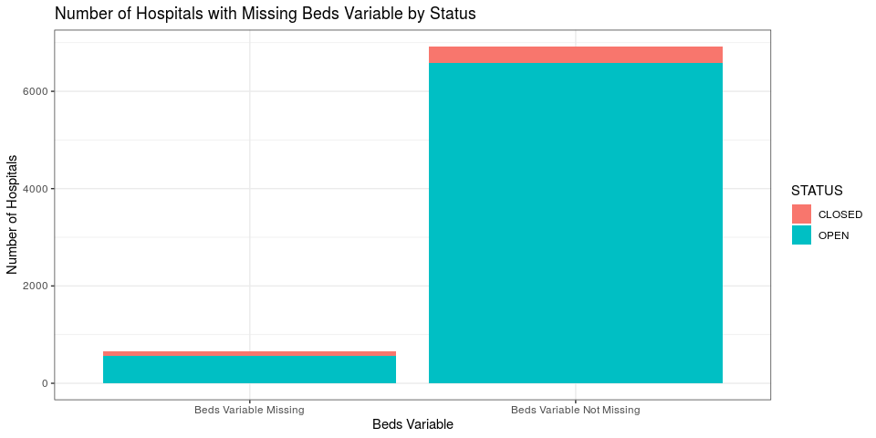

```r
#Run.

hospitals %>%
  mutate(BEDS_NA = ifelse(is.na(BEDS), "Beds Variable Missing", "Beds Variable Not Missing")) %>%
  ggplot(aes(x = BEDS_NA, fill = STATUS)) +
    geom_bar() +
  labs(title = "Number of Hospitals with Missing Beds Variable by Status", x = "Beds Variable", y = "Number of Hospitals", col = "Status") +
  theme_bw()
```

Incomplete data can also refer to sampling issues - or when the data that we have available does not represent enough of a population to draw conclusions. For instance, the cases data will only represent confirmed cases of Covid-19. It cannot represent those that have had the virus but have not been tested for it. This means that using this data to understand the extent of the spread may under-count areas with shortages of testing supplies, where testing has not been politically prioritized, or where there are higher populations with difficulty accessing testing.

Note that all data is to some degree incomplete. There is no such thing as a dataset that covers everything. However, here we are examining how the choices of what to include or exclude impact our data analysis.

In what ways might the incompleteness of your data fail to address the extent of the issues you had hoped to examine in your analysis? Describe in specific detail how the data’s incompleteness might affect your data analysis. Reference a specific analysis you’ve completed (either through transformation or plotting), and describe how this issue might impact how you interpret your data analysis.

```r
The medicare data only connects total discharges to each hospital-specific DRG. This makes it difficult to get an accurate detail on how many individual medicare patients were treated for each specific DRG. For instance, one individual patient could be counted twice or more in total discharges if they visited the same hospital for the same condition more than once in the year. My boxplot of total discharges throughout the U.S. in lab 6 could be more accurate with more precise data.  Furthermore, in regards to payments the dataset only reports averages not the total cost. This erases any possible outliers there could have been in the data and makes it difficult to generate any new average based on the total payments.
```